# Regresja i analiza wariancji - Laboratorium 4

Jednoczynnikowa analiza wariancji - podstawy

Adrian Kowalski

Politechnika Krakowska

# Podstawy

Zajmiemy się teraz techniką analizy wariancji (ANOVA). Służy ona do wnioskowania statystycznego na temat różnic w srednich wartościach zmiennej objaśnianej między grupami. Na początek przypomnijmy sobie, że znamy już narzędzie służące do porównywania średnich w momencie, gdy mamy tylko dwie grupy.

# Test T studenta

Przypomnimy teraz konstrukcję testu t studenta dla średniej dwóch niezależnych prób. Niech $\overline{x}_1, \overline{x}_2$ oznaczają średnią z prób $x_1, x_2$, $\mu_1, \mu_2$ średnią populacji odpowiednio $x_1,x_2$, $s_1^2, s_2^2$ wariancję z prób $x_1, x_2$ i wreszcie $n_1, n_2$ liczność prób $x_1,x_2$. Rozważać będziemy tutaj obustronną wersję testu t, zatem mamy
$$H_0:
\mu_1 = \mu_2, \\ H_1: \mu_1 \neq \mu_2.$$
Mieliśmy w tym wypadku dwa scenariusze, albo wariancja obu populacji była równa, albo te wariancje były rózne. W pierwszym wypadku statystyka testowa przyjmowała postać
$$t =
\frac{(\overline{x_1} - \overline{x_2}) - (\mu_1 - \mu_2))}{s_p
\sqrt{\frac{1}{n_1} + \frac{1}{n_2}}},$$
gdzie $s_p = \sqrt{\frac{(n_1 - 1)s^2_1 + (n_2 - 1)s_2^2}{n_1 + n_2 - 2}}$ to pierwiastek z tzw. łączonej wariancji prób $x_1, x_2$ (łączona wariancja pomaga, gdy próby mają różną wielkość). Ta statystyka ma rozkład $t$-studenta z $n_1 + n_2 - 2$ stopniami swobody. W wypadku różnych wariancji statystyka testowa ma postać
$$t = \frac{\overline{x_1} - \overline{x_2} -
(\mu_1 - \mu_2)}{\sqrt{\frac{s^2_1}{n_1}+\frac{s_2^2}{n_2}}}.$$
Ta statystyka ma rozkład $t$-studenta o $v$ pseudo-stopniach swobody, gdzie $v$ (tak zwana poprawka Welscha) dane jest wzorem
$$\frac{\left(\frac{s^2_1}{n_1}
+ \frac{s^2_2}{n_2} \right)^2}{\frac{\left(
\frac{s_1^2}{n_1}\right)^2}{n_1-1} + \frac{\left(
\frac{s_2^2}{n_2}\right)^2}{n_2-1}}.$$
Oczywiście $v$ nie zawsze jest liczbą całkowitą, więc najczęściej przybliżamy wartość $v$ liczbami całkowitymi, lub korzystamy z oprogramowania statystycznego, do wyznaczenia wartości krytycznej z rozkładu z takim parametrem.

W R test $t$-studenta wykonujemy oczywiście poleceniem t.test(). Równością wariancji w populacjach sterujemy parametrem “var.equal”. Wykonajmy przykładowy test $t$-studenta.

Na tych zajęciach zajmiemy się klasycznym zbiorem danych [Student Performance Data Set](https://archive.ics.uci.edu/ml/datasets/student+performance). Jest w nim bardzo dużo cech, ale skupimy się jedynie na kilku z nich.

```r
library(tidyverse)
student <- readr::read_csv('student-mat.csv')
head(student)
```

| school | sex | age | address | famsize | Pstatus | Medu | Fedu | Mjob | Fjob | reason | guardian | traveltime | studytime | failures | schoolsup | famsup | paid | activities | nursery | higher | internet | romantic | famrel | freetime | goout | Dalc | Walc | health | absences | … |
| --- | --- | --- | --- | --- | --- | --- | --- | --- | --- | --- | --- | --- | --- | --- | --- | --- | --- | --- | --- | --- | --- | --- | --- | --- | --- | --- | --- | --- | --- | --- |
| GP | F | 18 | U | GT3 | A | 4 | 4 | at_home | teacher | course | mother | 2 | 2 | 0 | yes | no | no | no | yes | yes | no | no | 4 | 3 | 4 | 1 | 1 | 3 | 6 | … |
| GP | F | 17 | U | GT3 | T | 1 | 1 | at_home | other | course | father | 1 | 2 | 0 | no | yes | no | no | no | yes | yes | no | 5 | 3 | 3 | 1 | 1 | 3 | 4 | … |
| GP | F | 15 | U | LE3 | T | 1 | 1 | at_home | other | other | mother | 1 | 2 | 3 | yes | no | yes | no | yes | yes | yes | no | 4 | 3 | 2 | 2 | 3 | 3 | 10 | … |
| GP | F | 15 | U | GT3 | T | 4 | 2 | health | services | home | mother | 1 | 3 | 0 | no | yes | yes | yes | yes | yes | yes | yes | 3 | 2 | 2 | 1 | 1 | 5 | 2 | … |
| GP | F | 16 | U | GT3 | T | 3 | 3 | other | other | home | father | 1 | 2 | 0 | no | yes | yes | no | yes | yes | no | no | 4 | 3 | 2 | 1 | 2 | 5 | 4 | … |
| GP | M | 16 | U | LE3 | T | 4 | 3 | services | other | reputation | mother | 1 | 2 | 0 | no | yes | yes | yes | yes | yes | yes | no | 5 | 4 | 2 | 1 | 2 | 5 | 10 | … |

```r
summary(student$G1)
```

```
   Min. 1st Qu.  Median    Mean 3rd Qu.    Max.
   3.00    8.00   11.00   10.91   13.00   19.00
```

```r
dplyr::sample_n(tbl=student,size=30)$G1
```

```
 [1]  9 12  6 15 10 14 16 10  8 18 14  7  9 14  7 12 10  5  5 13 13 11  6  9 12  8 11 13 13  7
```

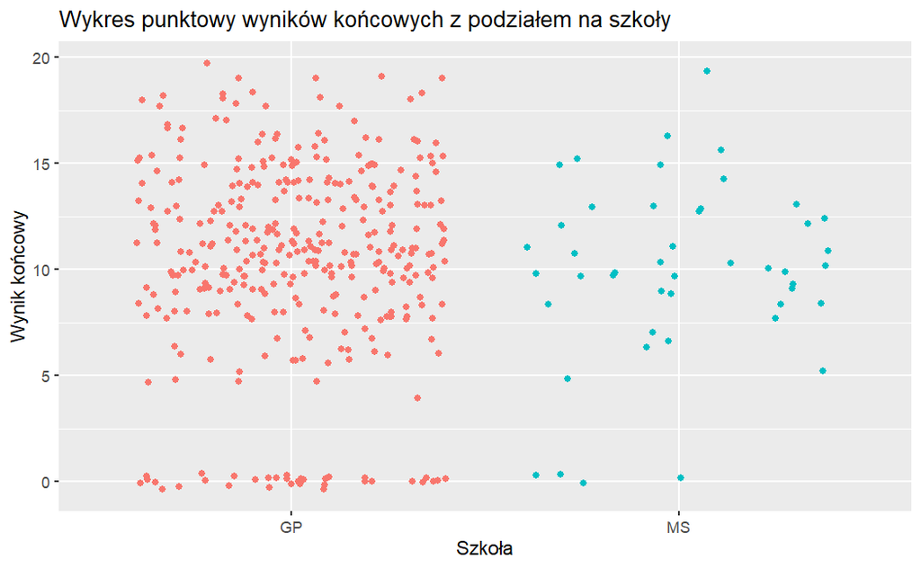

```r
ggplot(student, aes(x=school, y=G3)) + geom_point(aes(color=school), position='jitter') + labs(title = 'Wykres punktowy wyników końcowych z podziałem na szkoły', x='Szkoła', y='Wynik końcowy') + theme(legend.position = 'none')
```

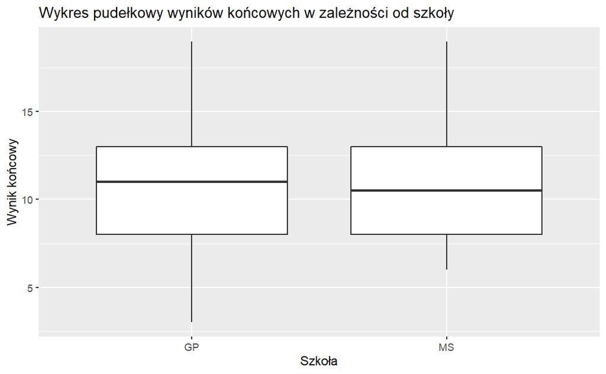

```r
ggplot(student, aes(x=school, y=G1)) + geom_boxplot() + labs(title = "Wykres pudełkowy wyników końcowych w zależności od szkoły", x='Szkoła', y='Wynik końcowy')
```

```r
t.test(G1 ~ school, data=student, var.equal=FALSE, alternative='two.sided')
```

```
    Welch Two Sample t-test

data:  G1 by school
t = 0.50699, df = 57.297, p-value = 0.6141
alternative hypothesis: true difference in means between group GP and group MS is not equal to 0
95 percent confidence interval:
 -0.7842532  1.3160832
sample estimates:
mean in group GP mean in group MS
        10.93983         10.67391
```

# Jednoczynnikowa Analiza Wariancji

W powyższych rozważaniach zakładaliśmy, że były tylko dwie kategorie, dlatego mogliśmy stosować test $t$-studenta. Na szczęście jeżeli mamy więcej grup, to mamy narzędzie do weryfikacji różnicy w średnich między tymi grupami. Tym narzędziem jest analiza wariancji. W klasycznej analizie wariancji zakładamy, że wariancja każdej z grup jest równa pewnej, tej samej, stałej. Do analizy wariancji używamy statystyki testowej $F$, która ma rozkład zwany rozkładem Snedecora-Fischera. Przy analizie wariancji zakładamy, że mamy próby pochodzące z $k$ grup $x_1, x_2, \dots, x_k$ o średnich $\mu_1, \mu_2, \dots, \mu_n$. Hipotezy naszego testu wyglądają następująco
$$H_0:
\mu_1 = \mu_2 = \dots = \mu_k, \\
H_1: \text{przynajmniej jedna ze średnich} \; \mu_i \; \text{jest różna
od pozostałych.}$$

Aby wyprowadzić statystykę testową użyjemy zwyczajowej notacji. $y_{ij}$ będzie oznaczało $j$-tą obserwację z $i$-tej grupy, $\overline{y}$ średnią bez podziału na grupy, a $\overline{y}_i$ średnią $i$-tej grupy. Wtedy zakładamy, że $y_{ij} = \overline{y} + (\overline{y}_i - \overline{y}) + (y_{ij} - \overline{y}_i)$, czyli że możemy rozłożyć obserwację na $3$ składniki: średnią wszystkich obserwacji, odchylenie średniej w grupie od całkowitej średniej i odchylenie obserwacji od średniej w grupie. Chcemy też rozbić całkowitą sumę kwadratów
$$SST =
\sum_{i,j} (y_{ij} - \overline{y})^2 = \sum_{i,j} y_{ij}^2 - \left(
\sum_{i,j} y_{ij} \right)^2,$$
gdzie sumujemy po wszystkich $i$ - grupach i wszystkich $j$ - obserwacjach w grupach. Na sumę kwadrtów pomiędzy grupami $SSA$ i sumę kwadratów wewnątrz grup $SSW$. Sumę kwadratów pomiędzy grupami wyznaczamy jako
$$SSA = \sum_{i=1}^k n_i(\overline{y}_i -
\overline{y})^2,$$
gdzie $n_i$ to liczność $i$-tej grupy. Natomiast sumę kwadratów wewnątrz grup wyznaczamy jako
$$SSW =
\sum_{i,j} (y_{ij} - \overline{y}_i)^2.$$
To pozwala nam zdefiniować średnią sumę kwadratów pomiędzy grupami $MSA = \frac{SSA}{k-1}$ i średnią sumę kwadratów wewnątrz grup $MSW= \frac{SSW}{n - k}$.Wtedy nasza statystyka testowa $F$ (przy założeniu $H_0$) ma postać
$$F = \frac{MSA}{MSW} = \frac{\frac{\sum_{i=1}^k
n_i(\overline{y}_i - \overline{y})^2}{k-1}}{\frac{\sum_{i,j} (y_{ij} -
\overline{y}_i)^2}{n-k}}.$$

Powyższa statystyka ma rozkład $F$ z parametrami $df_1 = k -1$, $df_2 = n - k$. W szczególności dla dwóch grup wygląda to następująco

$$F = \frac{n_1(\overline{y}_1 -
\overline{y})^2 + n_2(\overline{y}_2 -
\overline{y})^2}{\frac{\sum_{j=1}^{n_1}(y_{1j} - \overline{y}_1)^2 +
\sum_{j=1}^{n_2} (y_{2j} - \overline{y}_2)^2}{n-2}}$$

Można pokazać, że w powyższym wypadku $F = t^2$, więc dla dwóch prób o równej wariancji, analiza wariancji jest równoważna z testem $t$-studenta.

Analizę wariancji w R przeprowadzamy za pomocą polecenia aov(). Wprowadzamy do niej formuły podobnie jak przy poleceniu lm() “zmienna objasniana ~ podział na grupy”. Aby zobaczyć wynik analizy wariancji używamy standardowo funkcji summary().

```r
summary(aov(G1 ~ school, data=student))
```

```
             Df Sum Sq Mean Sq F value Pr(>F)
school        1      3   2.874    0.26   0.61
Residuals   393   4338  11.038
```

```r
student <- student %>% dplyr::mutate(Walc = as.character(Walc))
```

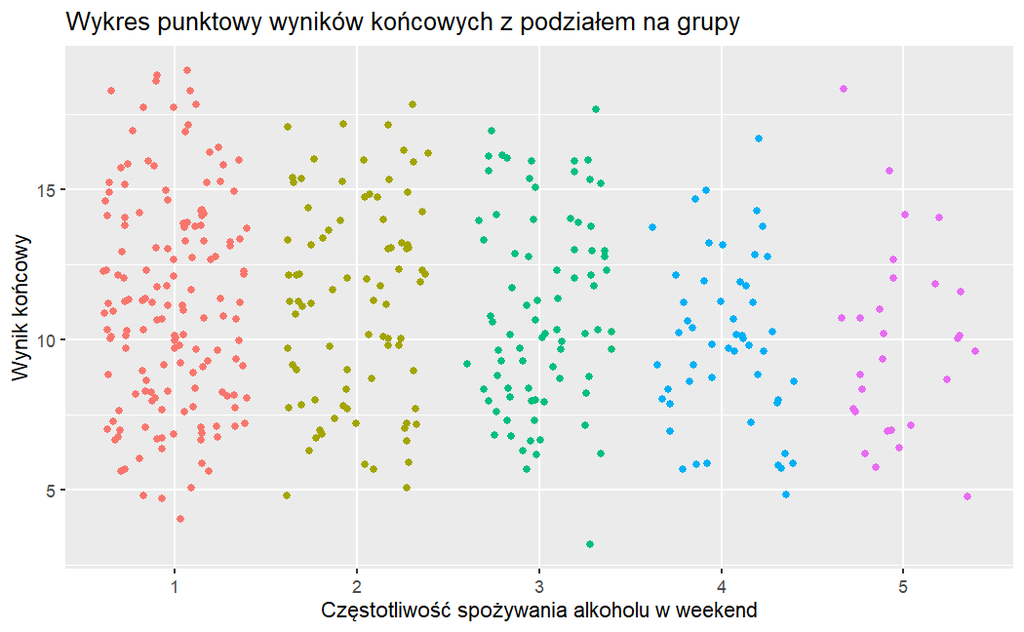

```r
ggplot(student, aes(x=Walc, y=G1)) + geom_point(aes(color=Walc), position='jitter') + labs(title = 'Wykres punktowy wyników końcowych z podziałem na grupy', x='Częstotliwość spożywania alkoholu w weekend', y='Wynik końcowy') + theme(legend.position = 'none')
```

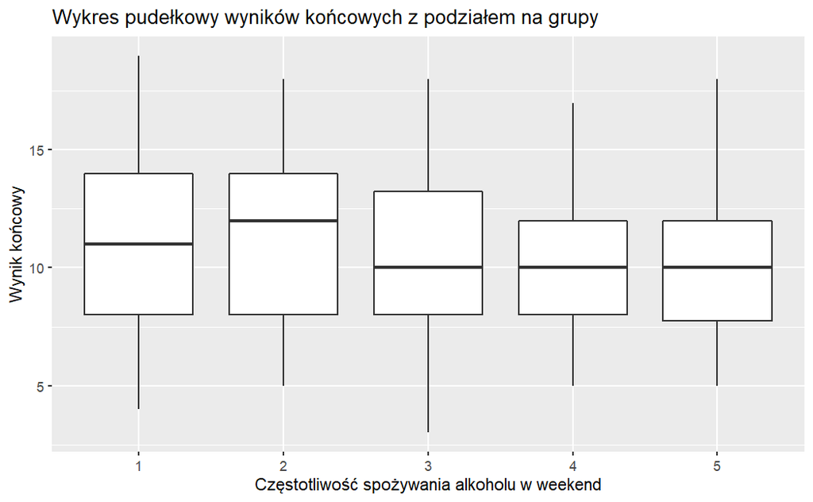

```r
ggplot(student, aes(x=Walc, y=G1)) + geom_boxplot() + labs(title = "Wykres pudełkowy wyników końcowych z podziałem na grupy", x='Częstotliwość spożywania alkoholu w weekend', y='Wynik końcowy')
```

```r
summary(aov(G1 ~ Walc, data=student))
```

```
             Df Sum Sq Mean Sq F value Pr(>F)
Walc          4     91   22.79   2.091 0.0813 .
Residuals   390   4250   10.90
---
Signif. codes:  0 ‘***’ 0.001 ‘**’ 0.01 ‘*’ 0.05 ‘.’ 0.1 ‘ ’ 1
```

# Analiza Tuckeya-Kramera

Analiza wariancji jest bardzo użytecznym narzędziem, ale ma jeden zasadniczy kłopot w interpretacji. Wynik analizy wariancji mówi nam jedynie o tym, że któraś z grup rózni się od pozostałych, a nie która z nich to jest. Na szczęście mamy narzędzie, które pomoże nam po odrzuceniu hipotezy zerowej analizy wariancji. Tym narzędziem jest procedura Tukeya-Kramera. W R procedurę Tukeya-Kramera wywołujemy poleceniem TukeyHSD(), podając jako argument nasz model analizy wariancji.

```r
student <- student %>% dplyr::mutate(freetime = as.character(freetime))
```

```r
summary(aov(G1 ~ freetime, data = student))
```

```
             Df Sum Sq Mean Sq F value  Pr(>F)
freetime      4    170   42.48   3.972 0.00358 **
Residuals   390   4171   10.69
---
Signif. codes:  0 ‘***’ 0.001 ‘**’ 0.01 ‘*’ 0.05 ‘.’ 0.1 ‘ ’ 1
```

```r
TukeyHSD(aov(G1 ~ freetime, data = student))
```

```
  Tukey multiple comparisons of means
    95% family-wise confidence level

Fit: aov(formula = G1 ~ freetime, data = student)

$freetime
          diff        lwr        upr     p adj
2-1  1.8889803 -0.4525101  4.2304706 0.1777651
3-1  0.2115320 -1.9654248  2.3884889 0.9988923
4-1  0.6768879 -1.5425694  2.8963452 0.9193417
5-1  1.6171053 -0.8800142  4.1142248 0.3898272
3-2 -1.6774482 -3.0066057 -0.3482908 0.0054224
4-2 -1.2120924 -2.6097723  0.1855875 0.1239003
5-2 -0.2718750 -2.0782870  1.5345370 0.9939133
4-3  0.4653559 -0.6346774  1.5653891 0.7744705
5-3  1.4055732 -0.1817793  2.9929258 0.1103762
5-4  0.9402174 -0.7049385  2.5853733 0.5200194
```

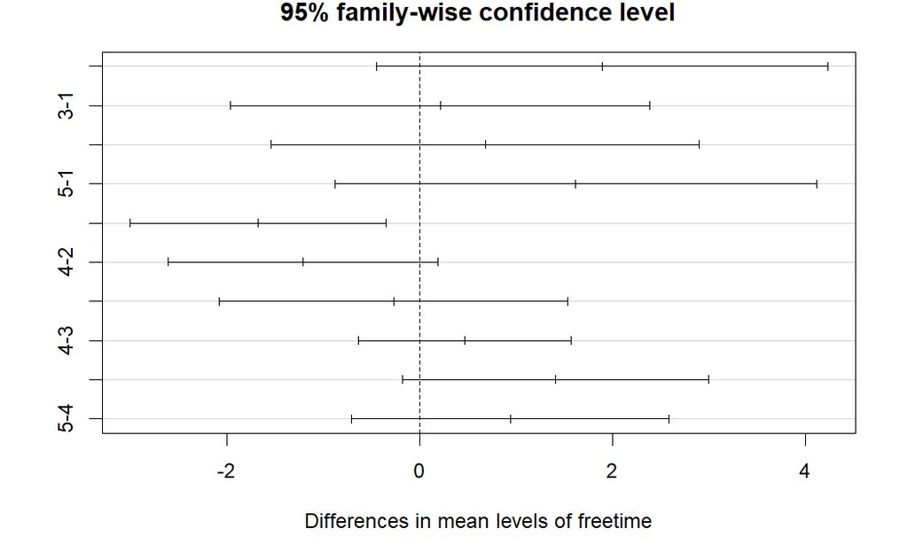

```r
plot(TukeyHSD(aov(G1 ~ freetime, data = student)))
```

# Ćwiczenie

Dalej korzystając z tego samego zbioru danych przeprowadź analizę wariancji dla innych zmiennych objaśniających, w wypadku odrzucenia hipotezy zerowej przeprowadź analizę Tukeya-Kramera.